# Does the CAPM price ASX large caps?

Time-series, cross-sectional and stability tests on 16 ASX stocks, 2015–2024

Author

Kai Marsh

Published

November 15, 2026

```r
library(tidyverse)
library(sandwich)
library(lmtest)
library(ggrepel)
library(knitr)

rf <- 0.002            # constant monthly risk-free proxy used by the data pipeline (~2.4% p.a.)
nw_lag <- 3            # Newey-West lag for monthly data

pct  <- function(x, d = 1) sprintf(paste0("%.", d, "f%%"), 100 * x)
num  <- function(x, d = 2) formatC(x, format = "f", digits = d)
nw   <- function(m) coeftest(m, vcov = NeweyWest(m, lag = nw_lag, prewhite = FALSE))

sector <- c(
  CBA = "Financials", NAB = "Financials", WBC = "Financials", ANZ = "Financials",
  MQG = "Financials", QBE = "Financials",
  BHP = "Resources & materials", RIO = "Resources & materials", AMC = "Resources & materials",
  CSL = "Other sectors", WOW = "Other sectors", COL = "Other sectors", WES = "Other sectors",
  TLS = "Other sectors", GMG = "Other sectors", ALL = "Other sectors"
)
sector_cols <- c("Financials" = "#2a78d6", "Resources & materials" = "#eb6834",
                 "Other sectors" = "#1baf7a")

theme_report <- theme_minimal(base_size = 11) +
  theme(panel.grid.minor = element_blank(),
        panel.grid.major = element_line(colour = "grey90", linewidth = 0.3),
        axis.title = element_text(colour = "grey30"),
        plot.title = element_text(face = "bold"),
        plot.title.position = "plot",
        legend.position = "top", legend.justification = "left",
        legend.title = element_blank())
```

```r
raw <- read_csv("../data/asx_returns.csv", show_col_types = FALSE)

r <- raw |>
  group_by(symbol) |> arrange(date) |>
  slice(-1) |>                                   # first month per stock is a partial month
  ungroup() |>
  mutate(ticker = sub("\\.AX$", "", symbol),
         sector = factor(sector[ticker], levels = names(sector_cols))) |>
  group_by(date) |>
  mutate(n_stocks = n(),
         mkt      = mean(ret),                           # equal-weight market (all stocks)
         mkt_loo  = (sum(ret) - ret) / (n_stocks - 1)) |> # leave-one-out market
  ungroup() |>
  mutate(ex = ret - rf, mex = mkt - rf, mex_loo = mkt_loo - rf)

mkt <- r |> distinct(date, mkt, mex) |> arrange(date)
n_months <- nrow(mkt)
mkt_prem_m <- mean(mkt$mex)
```

```r
fit_capm <- function(d) {
  m <- lm(ex ~ mex_loo, data = d)
  ct <- nw(m)
  tibble(alpha = ct[1, 1], t_alpha = ct[1, 3], p_alpha = ct[1, 4],
         beta = ct[2, 1], t_beta = ct[2, 3], r2 = summary(m)$r.squared,
         n = nobs(m), mean_ex = mean(d$ex))
}
ts <- r |> group_by(ticker, sector) |> group_modify(~ fit_capm(.x)) |> ungroup()

beta_shift <- r |> group_by(ticker) |>
  summarise(b_full = coef(lm(ex ~ mex))[2], b_loo = coef(lm(ex ~ mex_loo))[2]) |>
  mutate(d = b_full - b_loo)

sml <- lm(mean_ex ~ beta, data = ts)
sml_ct <- summary(sml)$coefficients
```

## Executive summary

- **Beta explains little of the cross-section of average returns.** Across 16 ASX large caps, a stock’s market beta has essentially no relationship with its average return. The fitted security market line is nearly flat, about 3% a year per unit of beta, against the 11% market premium the CAPM implies. Low-beta names such as CSL, RIO and Coles earned as much as the high-beta banks. This is the “low-beta anomaly” documented in US data, and it shows up here as well.
- **No individual stock has a convincing alpha, but the test has little power.** Only one of 16 CAPM intercepts is significant at 5% (ANZ, negative), and the joint GRS test does not reject the CAPM. With about 10 years of monthly data, the standard error on an annual alpha is around 4–6 percentage points, so even sizeable mispricing would go undetected.
- **Betas moved materially after 2020.** CBA, NAB, Goodman and Wesfarmers became significantly more market-sensitive in 2020–24, while BHP, RIO and CSL became less so. A single full-sample beta is a poor input for cost-of-capital or hedging decisions in this market.

## Problem

The Capital Asset Pricing Model (CAPM) says a stock’s expected excess return is proportional to its market beta: $E[R_i] - R_f = \beta_i \,(E[R_m] - R_f)$. It is still the default model for estimating the cost of equity in valuation and regulatory work in Australia. Most of the evidence on whether it holds comes from US data, yet the ASX is unusual: it is concentrated in banks and miners, and its returns are tied to commodity cycles.

This analysis asks three questions of a sample of ASX large caps:

1. **Time series:** are the CAPM intercepts (alphas) zero, individually and jointly?
2. **Cross section:** do higher-beta stocks earn higher average returns, and by the amount the market premium implies?
3. **Stability:** are betas stable enough over time to be used as forward-looking inputs?

## Data and approach

```r
sample_tbl <- r |>
  group_by(Ticker = ticker, Sector = sector) |>
  summarise(Months = n(), From = format(min(date), "%b %Y"),
            `Mean return (p.a.)` = pct(12 * mean(ret)),
            `Volatility (p.a.)` = pct(sqrt(12) * sd(ret)), .groups = "drop") |>
  arrange(Sector, Ticker)
```

- **Universe:** 16 ASX large caps across banking, insurance, resources, healthcare, retail, telecoms, property and gaming. Monthly total returns (from Yahoo Finance adjusted prices, via `tidyquant`) run from Feb 2015 to Dec 2024, 119 months in all. Each stock’s first month is dropped because it is a partial month. Coles (COL) only listed in November 2018, so it has 73 months.
- **Market proxy:** an equal-weighted portfolio of the same 16 stocks. Because each stock makes up 1/16 of this “market”, its beta is partly measured against itself. For every stock-level regression I therefore use a **leave-one-out** market (the equal-weighted return of the other 15 stocks). This lowers the estimated betas by 0.04–0.23.
- **Risk-free rate:** a constant 0.2% per month (≈2.4% p.a.), as in the data pipeline. A constant rate only shifts each alpha by $R_f(1-\beta_i)$. It has no effect on betas or on the cross-sectional slope.
- **Tests:**
  - Time-series CAPM regressions for each stock, with Newey–West standard errors (3 lags).
  - The Gibbons–Ross–Shanken (GRS) joint test of zero alphas.
  - A cross-sectional security market line.
  - Fama–MacBeth regressions on *rolling, pre-estimated* 36-month betas, which avoids testing on the same data used to estimate beta.
  - A split-sample comparison of betas before and after January 2020.

```r
kable(sample_tbl, align = "llrrrr", caption = "Sample: monthly returns, after dropping each stock's partial first month")
```

Sample: monthly returns, after dropping each stock’s partial first month

| Ticker | Sector | Months | From | Mean return (p.a.) | Volatility (p.a.) |
| --- | --- | --- | --- | --- | --- |
| ANZ | Financials | 119 | Feb 2015 | 6.8% | 21.8% |
| CBA | Financials | 119 | Feb 2015 | 12.2% | 20.0% |
| MQG | Financials | 119 | Feb 2015 | 20.4% | 24.8% |
| NAB | Financials | 119 | Feb 2015 | 9.0% | 21.4% |
| QBE | Financials | 119 | Feb 2015 | 13.1% | 27.0% |
| WBC | Financials | 119 | Feb 2015 | 7.5% | 22.3% |
| AMC | Resources & materials | 119 | Feb 2015 | 7.2% | 16.1% |
| BHP | Resources & materials | 119 | Feb 2015 | 15.1% | 25.6% |
| RIO | Resources & materials | 119 | Feb 2015 | 16.7% | 24.2% |
| ALL | Other sectors | 119 | Feb 2015 | 28.5% | 27.2% |
| COL | Other sectors | 73 | Dec 2018 | 13.1% | 18.8% |
| CSL | Other sectors | 119 | Feb 2015 | 15.0% | 19.4% |
| GMG | Other sectors | 119 | Feb 2015 | 23.0% | 24.0% |
| TLS | Other sectors | 119 | Feb 2015 | 1.9% | 17.3% |
| WES | Other sectors | 119 | Feb 2015 | 16.0% | 19.4% |
| WOW | Other sectors | 119 | Feb 2015 | 6.3% | 16.3% |

## Key findings

### 1. The security market line is flat

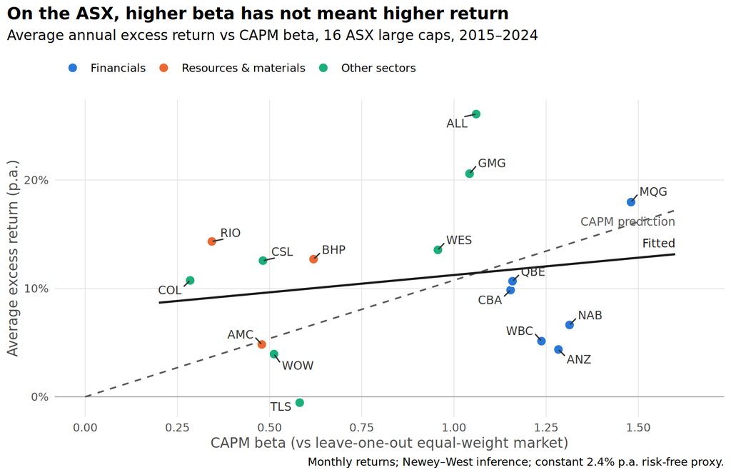

Figure 1: Average excess return against CAPM beta. The dashed line is what the CAPM predicts (through the origin and the market at β = 1). The solid line is the fitted cross-sectional relationship.

```r
capm_line <- tibble(beta = c(0, 1.6), y = 12 * c(0, 1.6) * mkt_prem_m)
fit_line  <- tibble(beta = c(0.2, 1.6), y = 12 * (sml_ct[1, 1] + sml_ct[2, 1] * c(0.2, 1.6)))

p_sml <- ggplot(ts, aes(beta, 12 * mean_ex)) +
  geom_hline(yintercept = 0, colour = "grey60", linewidth = 0.3) +
  geom_line(data = capm_line, aes(beta, y), linetype = "dashed", colour = "grey35", linewidth = 0.6) +
  geom_line(data = fit_line, aes(beta, y), colour = "grey10", linewidth = 0.8) +
  geom_point(aes(fill = sector), shape = 21, size = 3.2, colour = "white", stroke = 0.8) +
  geom_text_repel(aes(label = ticker), size = 3.2, colour = "grey20", seed = 1,
                  min.segment.length = 0.3, box.padding = 0.35) +
  annotate("text", x = 1.6, y = 12 * 1.6 * mkt_prem_m, label = "CAPM prediction",
           hjust = 1, vjust = 1.8, size = 3.2, colour = "grey35") +
  annotate("text", x = 1.6, y = 12 * (sml_ct[1, 1] + sml_ct[2, 1] * 1.6), label = "Fitted",
           hjust = 1, vjust = -0.8, size = 3.2, colour = "grey10") +
  scale_fill_manual(values = sector_cols) +
  scale_x_continuous(limits = c(0, 1.65), breaks = seq(0, 1.5, 0.25)) +
  scale_y_continuous(labels = scales::percent_format(accuracy = 1)) +
  labs(title = "On the ASX, higher beta has not meant higher return",
       subtitle = sprintf("Average annual excess return vs CAPM beta, 16 ASX large caps, %s–%s",
                          format(min(mkt$date), "%Y"), format(max(mkt$date), "%Y")),
       x = "CAPM beta (vs leave-one-out equal-weight market)",
       y = "Average excess return (p.a.)",
       caption = "Monthly returns; Newey–West inference; constant 2.4% p.a. risk-free proxy.") +
  theme_report

dir.create("../figures", showWarnings = FALSE)
ggsave("../figures/key_chart.png", p_sml, width = 8, height = 5.2, dpi = 200, bg = "white")
p_sml
```

The CAPM predicts that average excess returns rise one-for-one with beta along the dashed line. The fitted relationship is much flatter: an intercept of 8.0% a year and a slope of 3.2% per unit of beta (t = 0.69). The CAPM implies a zero intercept and a slope equal to the market premium (10.8%). Low-beta stocks (CSL, RIO, BHP, Coles) sit well above the CAPM line, and the big four banks sit well below it, even though the banks have the highest betas outside Macquarie.

Some of this is mechanical. A slope estimated across 16 stocks is noisy, and a beta estimated on the same data it is tested against is subject to errors-in-variables bias, which flattens the slope. The Fama–MacBeth test below deals with the second problem.

```r
dates <- sort(unique(r$date))
fm <- map_dfr(37:length(dates), function(k) {
  win <- r |> filter(date >= dates[k - 36], date < dates[k])
  b <- win |> group_by(ticker) |> filter(n() >= 24) |>
    summarise(b = coef(lm(ex ~ mex_loo))[2], .groups = "drop")
  cs <- r |> filter(date == dates[k]) |> inner_join(b, by = "ticker")
  if (nrow(cs) < 8) return(NULL)
  m <- lm(ex ~ b, data = cs)
  tibble(date = dates[k], g0 = coef(m)[1], g1 = coef(m)[2], mex = cs$mex[1])
})
nw_mean <- function(x) { m <- lm(x ~ 1); ct <- nw(m); c(est = ct[1, 1], t = ct[1, 3], p = ct[1, 4]) }
fm_g0 <- nw_mean(fm$g0); fm_g1 <- nw_mean(fm$g1); fm_mx <- nw_mean(fm$mex)
fm_gap <- nw_mean(fm$g1 - fm$mex)

fm_tbl <- tibble(
  Quantity = c("Intercept, γ₀ (CAPM: 0)", "Beta premium, γ₁ (CAPM: market premium)",
               "Market premium, same months", "γ₁ minus market premium"),
  `Monthly` = pct(c(fm_g0["est"], fm_g1["est"], fm_mx["est"], fm_gap["est"]), 2),
  `Annualised` = pct(12 * c(fm_g0["est"], fm_g1["est"], fm_mx["est"], fm_gap["est"])),
  `t (Newey–West)` = num(c(fm_g0["t"], fm_g1["t"], fm_mx["t"], fm_gap["t"]))
)
```

**Fama–MacBeth with out-of-sample betas.** Each month from Feb 2018, every stock’s beta is estimated over the previous 36 months only. That month’s excess returns are then regressed on those betas. Averaging over 83 months:

```r
kable(fm_tbl, align = "lrrr")
```

| Quantity | Monthly | Annualised | t (Newey–West) |
| --- | --- | --- | --- |
| Intercept, γ₀ (CAPM: 0) | 0.71% | 8.5% | 1.64 |
| Beta premium, γ₁ (CAPM: market premium) | 0.21% | 2.5% | 0.44 |
| Market premium, same months | 0.97% | 11.7% | 2.53 |
| γ₁ minus market premium | -0.76% | -9.1% | -1.63 |

The result is the same with out-of-sample betas. The price of beta risk is small and statistically indistinguishable from zero. Meanwhile, the market itself earned a significant premium over the same months. The gap between the two is -9.1% a year (t = -1.63). It points in the direction of a flatter-than-CAPM line, but with 16 stocks it is not statistically decisive. The pattern matches Black’s zero-beta CAPM and the “betting against beta” evidence of Frazzini and Pedersen (2014): the line has a positive intercept and a slope below the market premium.

### 2. Alphas: none convincing, but the test is weak

```r
grs_data <- r |> filter(ticker != "COL")                     # balanced panel
Y <- grs_data |> select(date, ticker, ex) |>
  pivot_wider(names_from = ticker, values_from = ex) |> arrange(date) |> select(-date) |> as.matrix()
f <- grs_data |> distinct(date, mex) |> arrange(date) |> pull(mex)
T_ <- nrow(Y); N_ <- ncol(Y)
X <- cbind(1, f); B <- solve(crossprod(X), crossprod(X, Y)); E <- Y - X %*% B
Sigma <- crossprod(E) / (T_ - 2); a <- B[1, ]
grs <- (T_ - N_ - 1) / N_ * drop(t(a) %*% solve(Sigma) %*% a) / (1 + mean(f)^2 / mean((f - mean(f))^2))
grs_p <- pf(grs, N_, T_ - N_ - 1, lower.tail = FALSE)

alpha_tbl <- ts |>
  arrange(desc(beta)) |>
  transmute(Ticker = ticker, Sector = sector,
            `Beta` = num(beta), `t(β)` = num(t_beta, 1),
            `Alpha (p.a.)` = pct(12 * alpha), `t(α)` = num(t_alpha),
            `R²` = num(r2), Months = n)
se_alpha_ann <- median(12 * ts$alpha / ts$t_alpha)
```

```r
kable(alpha_tbl, align = "llrrrrrr",
      caption = "Time-series CAPM regressions, leave-one-out equal-weight market, Newey–West t-statistics (3 lags)")
```

Time-series CAPM regressions, leave-one-out equal-weight market, Newey–West t-statistics (3 lags)

| Ticker | Sector | Beta | t(β) | Alpha (p.a.) | t(α) | R² | Months |
| --- | --- | --- | --- | --- | --- | --- | --- |
| MQG | Financials | 1.48 | 9.1 | 2.8% | 0.51 | 0.56 | 119 |
| NAB | Financials | 1.31 | 9.4 | -7.9% | -1.81 | 0.61 | 119 |
| ANZ | Financials | 1.28 | 9.7 | -10.0% | -2.27 | 0.56 | 119 |
| WBC | Financials | 1.24 | 10.4 | -8.7% | -1.79 | 0.50 | 119 |
| QBE | Financials | 1.16 | 5.1 | -1.8% | -0.24 | 0.30 | 119 |
| CBA | Financials | 1.15 | 13.5 | -2.6% | -0.78 | 0.55 | 119 |
| ALL | Other sectors | 1.06 | 4.6 | 15.8% | 1.91 | 0.25 | 119 |
| GMG | Other sectors | 1.04 | 6.0 | 10.1% | 1.69 | 0.32 | 119 |
| WES | Other sectors | 0.96 | 9.8 | 3.4% | 0.84 | 0.41 | 119 |
| BHP | Resources & materials | 0.62 | 5.4 | 6.1% | 0.83 | 0.10 | 119 |
| TLS | Other sectors | 0.58 | 6.2 | -7.3% | -1.55 | 0.20 | 119 |
| WOW | Other sectors | 0.51 | 4.7 | -1.8% | -0.44 | 0.18 | 119 |
| CSL | Other sectors | 0.48 | 3.5 | 7.4% | 1.26 | 0.11 | 119 |
| AMC | Resources & materials | 0.48 | 4.9 | -0.5% | -0.12 | 0.16 | 119 |
| RIO | Resources & materials | 0.34 | 2.4 | 10.7% | 1.56 | 0.04 | 119 |
| COL | Other sectors | 0.28 | 1.3 | 7.0% | 1.07 | 0.05 | 73 |

- **Individually:** 1 of 16 alphas is significant at the 5% level: ANZ, at -10.0% a year. With 16 tests, roughly one false positive is expected by chance.
- **Jointly:** the GRS statistic on the 15 stocks with full histories is 1.17 (p = 0.31). The CAPM is not rejected.
- **Power:** the median standard error on an annualised alpha is about 5.2%. An alpha would need to be roughly ±10% a year to register as significant. “Not rejected” here means “not enough data to tell”, not “the CAPM fits”.

The market explains on average 31% of a stock’s monthly variance. That figure is high for the banks (50–60%) and low for the miners and defensives (4–20%). Low R² for BHP and RIO partly reflects the market proxy, which is dominated by financials (6 of 16 stocks). Against a cap-weighted ASX 200 the miners’ betas would be higher.

### 3. Betas shifted after 2020

```r
r2 <- r |> mutate(period = if_else(date < as.Date("2020-01-01"), "2015–19", "2020–24"))
split_b <- r2 |> group_by(ticker, sector, period) |> filter(n() >= 24) |>
  summarise(beta = coef(lm(ex ~ mex_loo))[2], .groups = "drop")
chow <- r2 |> group_by(ticker) |> group_modify(~ {
  if (n_distinct(.x$period) < 2) return(tibble(d_beta = NA_real_, p = NA_real_))
  ct <- nw(lm(ex ~ mex_loo * period, data = .x))
  tibble(d_beta = ct[4, 1], p = ct[4, 4])
}) |> ungroup()
wide <- split_b |> pivot_wider(names_from = period, values_from = beta) |>
  left_join(chow, by = "ticker") |> filter(!is.na(`2015–19`)) |>
  mutate(ticker = fct_reorder(ticker, `2020–24` - `2015–19`))
beta_cor <- cor(wide$`2015–19`, wide$`2020–24`)
sig_up   <- wide |> filter(p < 0.05, d_beta > 0) |> pull(ticker) |> as.character()
```

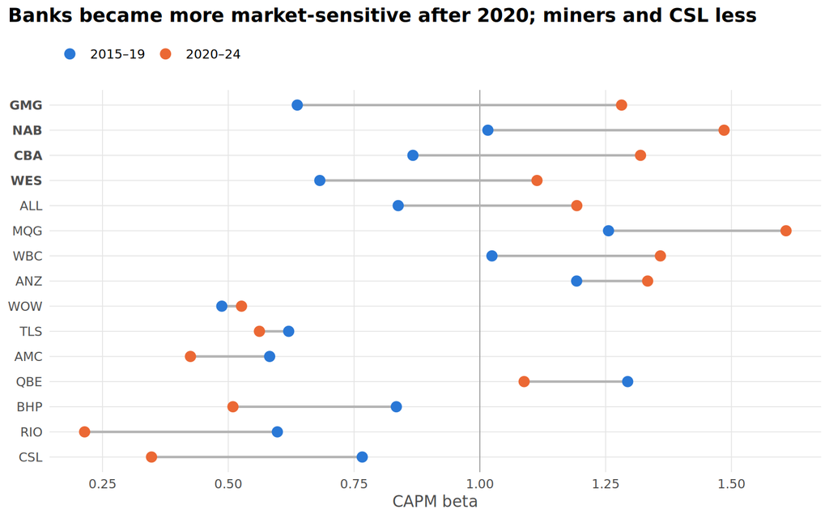

Figure 2: CAPM beta estimated separately for 2015–19 and 2020–24. Stocks ordered by the change. Bold tickers: change significant at 5% (Newey–West interaction test). Coles excluded (listed late 2018).

```r
long <- wide |> select(ticker, `2015–19`, `2020–24`) |>
  pivot_longer(-ticker, names_to = "period", values_to = "beta")
p_stab <- ggplot(wide, aes(y = ticker)) +
  geom_vline(xintercept = 1, colour = "grey60", linewidth = 0.3) +
  geom_segment(aes(x = `2015–19`, xend = `2020–24`, yend = ticker), colour = "grey70", linewidth = 0.8) +
  geom_point(data = long, aes(x = beta, colour = period), size = 3) +
  scale_colour_manual(values = c("2015–19" = "#2a78d6", "2020–24" = "#eb6834")) +
  scale_x_continuous(breaks = seq(0, 1.75, 0.25)) +
  labs(title = "Banks became more market-sensitive after 2020; miners and CSL less",
       x = "CAPM beta", y = NULL) +
  theme_report +
  theme(axis.text.y = element_text(face = ifelse(levels(wide$ticker) %in% wide$ticker[wide$p < 0.05],
                                                 "bold", "plain")))
ggsave("../figures/beta_stability.png", p_stab, width = 8, height = 5, dpi = 200, bg = "white")
p_stab
```

The two sets of betas are correlated (ρ = 0.68), so the ranking is broadly persistent, but the levels moved a lot. Betas for CBA, NAB, Goodman (GMG) and Wesfarmers (WES) rose significantly, by 0.43–0.64. All four banks moved above 1.3. Over the same period BHP, RIO and CSL became less tied to the market, though not significantly so individually. One plausible reading: after COVID, the rate cycle drove much of the broad market’s movement, and banks and property are the most rate-sensitive names in the sample. A cost-of-equity estimate based on a 2015–19 beta would have understated CBA’s by about 0.45 × the market premium.

## Tools

R (tidyverse, `tidyquant` for data, `sandwich`/`lmtest` for Newey–West inference, `ggplot2`/`ggrepel`), Quarto. The GRS test and Fama–MacBeth regressions are implemented directly.

## Limitations

- **Market proxy.** An equal-weighted index of the same 16 stocks is not the market. It overweights financials and underweights the miners relative to the ASX 200. Using the leave-one-out version removes the self-inclusion bias, but not the composition problem. All betas here are relative to this proxy.
- **Constant risk-free rate.** The RBA cash rate ranged from 0.10% to 4.35% over the sample. This affects the alpha levels (by $R_f(1-\beta)$), not the betas or slopes.
- **Small, survivor-selected universe.** These are today’s large caps, chosen with hindsight. That biases average returns upward and gives the cross-sectional tests 16 data points.
- **Sample length.** About 10 years of monthly data is short for estimating expected returns. Standard errors on mean returns are several percentage points a year.

## Next steps

- Replace the proxy market with the S&P/ASX 200 accumulation index and use the RBA cash rate or the 90-day bank bill rate for the risk-free rate.
- Expand to the ASX 200 constituents, including delisted stocks, and test on beta-sorted portfolios rather than individual stocks.
- Build proper SMB and HML factors from shares outstanding and book equity (the current pipeline’s price-based proxies are not suitable for inference).
- Repeat for HKEX, SGX and China A-shares.

## References

- Black, F. (1972). Capital market equilibrium with restricted borrowing. *Journal of Business*, 45(3), 444–455.
- Fama, E. F., & MacBeth, J. D. (1973). Risk, return, and equilibrium: Empirical tests. *Journal of Political Economy*, 81(3), 607–636.
- Frazzini, A., & Pedersen, L. H. (2014). Betting against beta. *Journal of Financial Economics*, 111(1), 1–25.
- Gibbons, M. R., Ross, S. A., & Shanken, J. (1989). A test of the efficiency of a given portfolio. *Econometrica*, 57(5), 1121–1152.